# Machine Learning Class Project

### 2.2 “train” function, still without cross validation, treating the object as a “formula class”. This should be identical to the above, just trying to understand the semantics.

```r
set.seed(123)
message("the above can also be used in the formula form:")
```

```
## the above can also be used in the formula form:
```

```r
p.training2PC.use.for<-data.frame("classe"=p.training1$classe,p.training2PC.use) #put in the same data frame so that the formula form can be used
modelFit.for <- train(classe~., data = p.training2PC.use.for, method = "knn")
message("this is a formula class, it doesn't accept trControl, so no effect on the k-fold.")
```

```
## this is a formula class, it doesn't accept trControl, so no effect on the k-fold.
```

```r
training2.for.pred<-predict(modelFit.for,p.training2PC.use.for)
message("Accuracy:")
```

```
## Accuracy:
```

```r
confusionMatrix(p.training1$classe,training2.for.pred)[[3]]
```

```
##       Accuracy          Kappa  AccuracyLower  AccuracyUpper   AccuracyNull
##   9.899602e-01   9.873004e-01   9.884648e-01   9.913077e-01   2.851901e-01
## AccuracyPValue  McnemarPValue
##   0.000000e+00   1.216895e-06
```

```r
message("#outcome from the single model prediction with method class")
```

```
## #outcome from the single model prediction with method class
```

```r
table(p.training2PC$user_name,training2.for.pred)
```

```
##           training2.for.pred
##               A    B    C    D    E
##   adelmo   1163  779  757  508  685
##   carlitos  838  675  518  478  603
##   charles   902  741  550  630  713
##   eurico    868  592  488  579  543
##   jeremy   1182  467  670  520  563
##   pedro     643  499  504  467  497
```

### 2.3 Training with “train” function, with 10-fold cross validation.

```r
# names(getModelInfo()) to see a list of methods
#k-fold=10
# Define training control
set.seed(123)
train.control <- trainControl(method = "cv", number = 10) #set up for 10 fold cross validation
# Train the model


modelFitK <- train(x = p.training2PC.use, y = p.training1$classe,method = "knn",trControl = train.control)
training2K.pred<-predict(object=modelFitK, newdata=p.training2PC.use)
message("Accuracy:")
```

```
## Accuracy:
```

```r
confusionMatrix(training2K.pred,p.training1$classe)[[3]] # rpart can do this explicitly
```

```
##       Accuracy          Kappa  AccuracyLower  AccuracyUpper   AccuracyNull
##   9.899602e-01   9.873004e-01   9.884648e-01   9.913077e-01   2.843747e-01
## AccuracyPValue  McnemarPValue
##   0.000000e+00   2.474948e-06
```

```r
# note: formula form doesn't work with trControl!  So can't do k-fold in formula form.
message("outcome from knn model with 10-fold cv:")
```

```
## outcome from knn model with 10-fold cv:
```

```r
table(p.training2PC$user_name,training2K.pred)
```

```
##           training2K.pred
##               A    B    C    D    E
##   adelmo   1163  779  757  508  685
##   carlitos  838  675  518  478  603
##   charles   902  741  550  630  713
##   eurico    868  592  488  579  543
##   jeremy   1181  469  669  520  563
##   pedro     643  499  504  467  497
```

### 2.4 Training with “rpart” function, without cross validation.

This is really fast compared to the knn method. But the accuracy is only 0.6.

```r
#back up a step
# assess training data all at once
#http://t-redactyl.io/blog/2015/10/using-k-fold-cross-validation-to-estimate-out-of-sample-accuracy.html
set.seed(123)
model.single<-rpart(classe ~ ., data=p.training2PC.use.for,method="class")

predict.single<-predict(object=model.single,newdata=p.training2PC.use.for, type="class")
message("Accuracy:")
```

```
## Accuracy:
```

```r
confusionMatrix(predict.single, p.training2PC.use.for$classe)[[3]] #ok this makes more sense, accuracy of 0.64.
```

```
##       Accuracy          Kappa  AccuracyLower  AccuracyUpper   AccuracyNull
##   5.993273e-01   4.878122e-01   5.924310e-01   6.061941e-01   2.843747e-01
## AccuracyPValue  McnemarPValue
##   0.000000e+00  3.439091e-232
```

```r
message("outcome from the single model prediction with method class")
```

```
## outcome from the single model prediction with method class
```

```r
table(p.training2PC$user_name,predict.single)
```

```
##           predict.single
##               A    B    C    D    E
##   adelmo   1513  639  785  333  622
##   carlitos  768  246  485  889  724
##   charles  1144  645  593  451  703
##   eurico   1258  695  252  273  592
##   jeremy   1257  220 1109  403  413
##   pedro    1265  403  407  293  242
```

### 2.5 Training with “rpart” function with 10-fold cross validation, as well as with repeat 10-fold cv, which reports a 95% confidence interval for the estimated accuracy.

```r
#Estimating out-of-sample accuracy
#k-fold cross validation
set.seed(123)

k.folds <- function(k) {
  folds <- createFolds(p.training2PC.use.for$classe, k = k, list = TRUE, returnTrain = TRUE)
  for (i in 1:k) {
    model <- rpart(classe ~ .,
                   data = p.training2PC.use.for[folds[[i]],], method = "class")
    predictions <- predict(object = model, newdata = p.training2PC.use.for[-folds[[i]],], type = "class")
    accuracies.dt <- c(accuracies.dt,
                       confusionMatrix(predictions, p.training2PC.use.for[-folds[[i]], ]$classe)$overall[[1]])
  }
  accuracies.dt
}

set.seed(123)
accuracies.dt <- c()
accuracies.dt <- k.folds(10)
message("Accuracies from each fold:")
```

```
## Accuracies from each fold:
```

```r
accuracies.dt
```

```
##  [1] 0.5830785 0.5588985 0.5883851 0.5718654 0.5901222 0.5733945 0.5953109
##  [8] 0.5864355 0.5756495 0.6009174
```

```r
message("Mean Accuracy:")
```

```
## Mean Accuracy:
```

```r
mean(accuracies.dt)
```

```
## [1] 0.5824058
```

```r
## repeat k-fold
set.seed(123)
v <- c()
v <- replicate(10, k.folds(10)) #this takes a long time. Reduce the replicate to 10 just to get an idea.
accuracies.dt <- c()
for (i in 1 : 10) {
  accuracies.dt <- c(accuracies.dt, v[,i])
}

mean.accuracies <- mean(accuracies.dt)
lci <- mean(accuracies.dt) - sd(accuracies.dt) * 1.96
uci <- mean(accuracies.dt) + sd(accuracies.dt) * 1.96
message("histogram of accuracies using repeat 10-fold CV:")
```

```
## histogram of accuracies using repeat 10-fold CV:
```

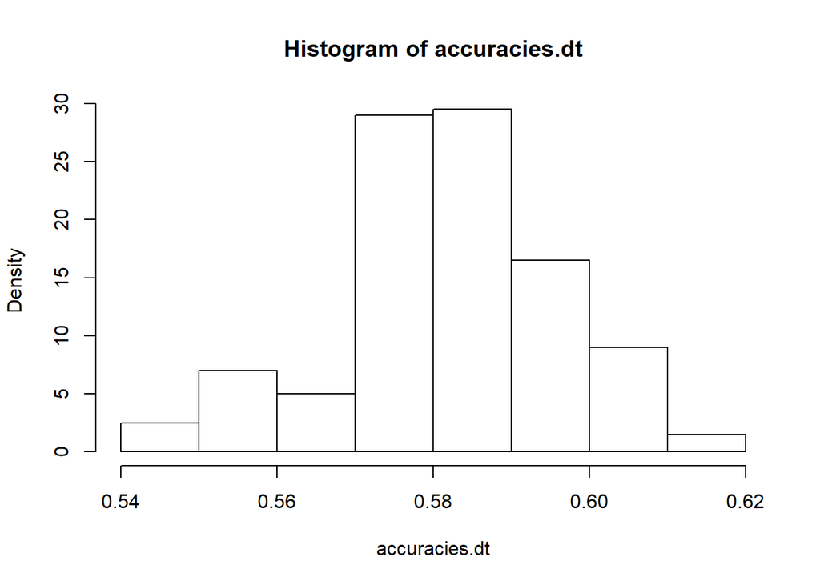

```r
hist(accuracies.dt,freq=F)
```

```r
message("Mean Accuracy, Lower CI, Upper CI")
```

```
## Mean Accuracy, Lower CI, Upper CI
```

```r
c(mean.accuracies, lci, uci)
```

```
## [1] 0.5816600 0.5549012 0.6084188
```